# A1

# Apply Normalization

Set seed for randomly sampling data for boxplot and density graphs before and after normalization.

```r
set.seed(12345)
randomSamplePOS <- sample(mergedDataNoDup[2:431], 10)
randomSampleNEG <- sample(mergedDataNoDup[432:485], 10)
randomSample <- cbind(randomSamplePOS,randomSampleNEG, mergedDataNoDup$ensembl_gene_id)
```

Define groups to use in normalization

```r
samples <- data.frame(lapply(colnames(randomSample[1:20]),
        FUN=function(x){unlist(strsplit(x,
                        split = "_"))[c(2,1)]}))
colnames(samples) <- colnames(randomSample[1:20])
rownames(samples) <- c("patients","cell_type")
samples <- data.frame(t(samples))
```

Applying TMM to data

```r
filtered_data_matrix <- as.matrix(randomSample[1:20])
rownames(filtered_data_matrix) <- randomSample$`mergedDataNoDup$ensembl_gene_id`
d = DGEList(counts=filtered_data_matrix, group=samples$cell_type)

d = calcNormFactors(d)

normalized_counts <- cpm(d)
```

## Not normalized plots

Boxplot for non-normalized data

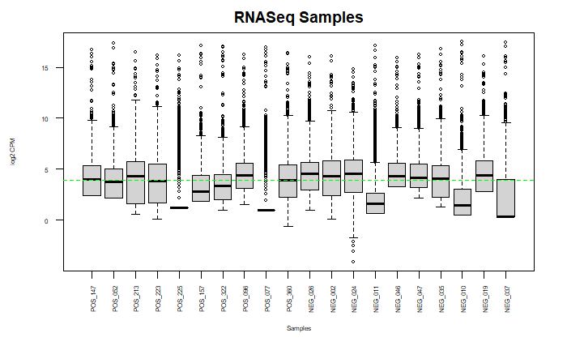

```r
data2plot <- log2(cpm(randomSample[1:20]))
boxplot(data2plot, xlab = "Samples", ylab = "log2 CPM",
        las = 2, cex = 0.5, cex.lab = 0.5,
        cex.axis = 0.5, main = "RNASeq Samples")
#draw the median on each box plot
abline(h = median(apply(data2plot, 2, median)),
       col = "green", lwd = 0.6, lty = "dashed")
```

Density plot for non-normalized data

```r
counts_density <- apply(log2(cpm(randomSample[1:20])),
                        2, density)
  #calculate the limits across all the samples
    xlim <- 0; ylim <- 0
    for (i in 1:length(counts_density)) {
      xlim <- range(c(xlim, counts_density[[i]]$x));
      ylim <- range(c(ylim, counts_density[[i]]$y))
    }
    cols <- rainbow(length(counts_density))
    ltys <- rep(1, length(counts_density))
    #plot the first density plot to initialize the plot
    plot(counts_density[[1]], xlim=xlim, ylim=ylim, type="n",
         ylab="Smoothing density of log2-CPM",
         main="", cex.lab = 0.85)
    #plot each line
    for (i in 1:length(counts_density))
      lines(counts_density[[i]], col=cols[i], lty=ltys[i])
```

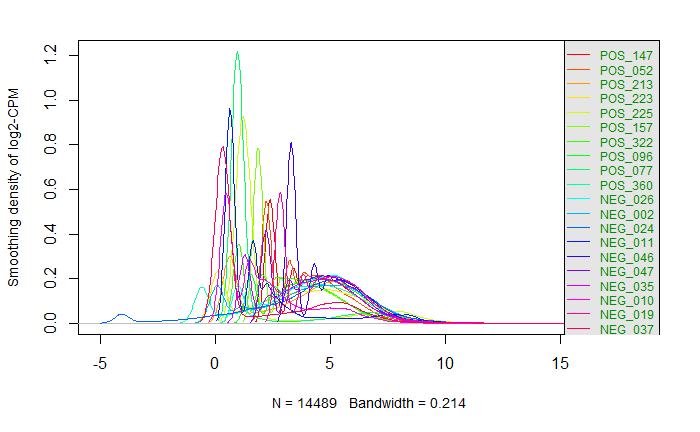

```r
    #create legend
    legend("topright", colnames(data2plot), legend = colnames(randomSample[1:20]),
           col=cols, lty=ltys, cex=0.75,
           border ="blue",  text.col = "green4",
           merge = TRUE, bg = "gray90")
```

## Normalized Plots

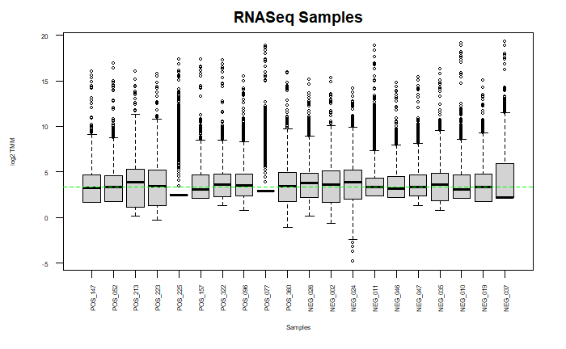

```r
data2plotNorm <- log2(normalized_counts)
boxplot(data2plotNorm, xlab = "Samples", ylab = "log2 TMM",
        las = 2, cex = 0.5, cex.lab = 0.5,
        cex.axis = 0.5, main = "RNASeq Samples")
#draw the median on each box plot
abline(h = median(apply(data2plotNorm, 2, median)),
       col = "green", lwd = 0.6, lty = "dashed")
```

Density plot for normalized data

```r
countsDensityNorm <- apply(log2(normalized_counts),
                        2, density)
  #calculate the limits across all the samples
    xlim <- 0; ylim <- 0
    for (i in 1:length(countsDensityNorm)) {
      xlim <- range(c(xlim, countsDensityNorm[[i]]$x));
      ylim <- range(c(ylim, countsDensityNorm[[i]]$y))
    }
    cols <- rainbow(length(countsDensityNorm))
    ltys <- rep(1, length(countsDensityNorm))
    #plot the first density plot to initialize the plot
    plot(countsDensityNorm[[1]], xlim=xlim, ylim=ylim, type="n",
         ylab="Smoothing density of log2-TMM",
         main="", cex.lab = 0.85)
    #plot each line
    for (i in 1:length(countsDensityNorm))
      lines(countsDensityNorm[[i]], col=cols[i], lty=ltys[i])
```

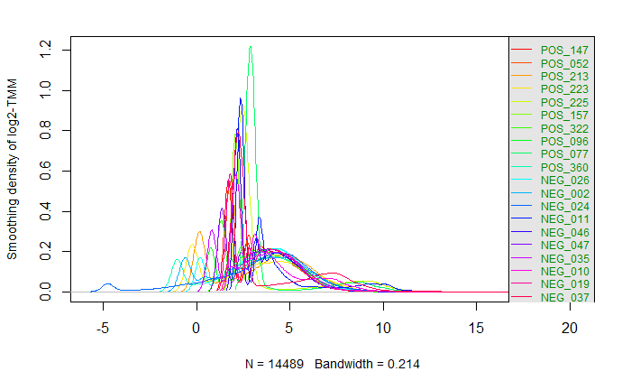

```r
    #create legend
    legend("topright", colnames(data2plotNorm), legend = colnames(normalized_counts),
           col=cols, lty=ltys, cex=0.75,
           border ="blue",  text.col = "green4",
           merge = TRUE, bg = "gray90")
```

Define groups for MDS plot

```r
samplesNorm <- data.frame(lapply(colnames(normalized_counts),
        FUN=function(x){unlist(strsplit(x,
                        split = "_"))[c(2,1)]}))
colnames(samplesNorm) <- colnames(normalized_counts)
rownames(samplesNorm) <- c("patients","cell_type")
samplesNorm <- data.frame(t(samplesNorm))
```

MDS for normalized data

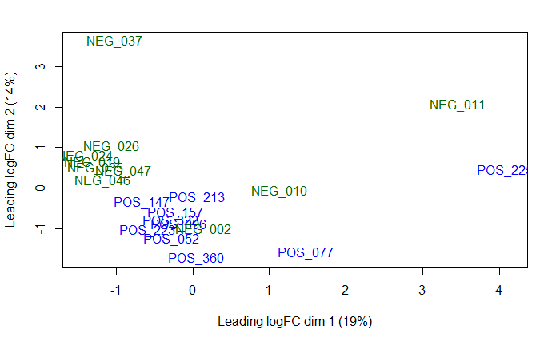

```r
plotMDS(d, labels=rownames(samplesNorm),
  col = c("darkgreen","blue")[factor(samplesNorm$cell_type)])
```

# Final dataset

Formatting final dataset

```r
rownames(mergedDataNoDup) <- mergedDataNoDup$HUGO

dim(mergedDataNoDup)
```

```
[1] 14489   486
```

**Important notes about code idea** The normalization was done with only the 20 randomly sampled data because a boxplot, and density plot with over 400 samples was too chaotic. The sample takes 10 control, and 10 case randomly from the whole dataset. Because of this only 20 samples were normalized for the analysis of plots.

**What are the control and test conditions of the dataset?** The control is the NEG columns in the dataset that are not effected by SARS-COV-2, and the test is the POS are patients with SARS-COV-2 positive results from nasopharyngeal swabs.

**Why is the dataset of interest to you?** My current BCB330Y1 research is about genetic association studies with SARS-Cov-2. I wanted to learn more about the topic, and use my time efficiently to expand my knowledge in this area.

**Were there expression values that were not unique for specific genes? How did you handle these?** There were no cases of expression values that were not unique for specific genes. However there were cases where there were multiple Ensemblid for a single gene id given in the raw data. Took care of this by only keeping one Ensemblid and discarding the rest.

# References

All Code and statistics were heavily taken from **Lecture 4 - Exploring the data and Lecture 4 - Exploring the data and basics of Normalization basics of Normalization** by Ruth Isserlin.

(Lieberman et al. 2020)

Durinck, Steffen, Paul T. Spellman, Ewan Birney, and Wolfgang Huber. 2009. “Mapping Identifiers for the Integration of Genomic Datasets with the r/Bioconductor Package biomaRt.” *Nature Protocols* 4: 1184–91.

Lieberman, Nicole AP, Vikas Peddu, Hong Xie, Lasata Shrestha, Meei-Li Huang, Megan C Mears, Maria N Cajimat, et al. 2020. “In Vivo Antiviral Host Transcriptional Response to SARS-CoV-2 by Viral Load, Sex, and Age.” *PLoS Biology* 18 (9): e3000849.

Morgan, Martin. 2022. *BiocManager: Access the Bioconductor Project Package Repository*. https://CRAN.R-project.org/package=BiocManager.

Robinson, Mark D, Davis J McCarthy, and Gordon K Smyth. 2010. “edgeR: A Bioconductor Package for Differential Expression Analysis of Digital Gene Expression Data.” *Bioinformatics* 26 (1): 139–40. https://doi.org/10.1093/bioinformatics/btp616.

Xie, Yihui. 2023. *Knitr: A General-Purpose Package for Dynamic Report Generation in r*. https://yihui.org/knitr/.

Zhu, Yuelin, Sean Davis, Robert Stephens, Paul S. Meltzer, and Yidong Chen. 2008. “GEOmetadb: Powerful Alternative Search Engine for the Gene Expression Omnibus.” *Bioinformatics (Oxford, England)* 24 (23): 2798–2800. https://doi.org/10.1093/bioinformatics/btn520.